# Solution to the Quantium Data Analytics Virtual Internship Program - TASk 1

Chinonso Emezie

15/09/2021

#Load required libraries

```r
library(tidyverse)
library(data.table)
```

```r
library(ggplot2)
library(ggmosaic)
library(readr)
library(stringr)
library(lessR)
library(scales)
```

#Import transaction data set and purchase behavior data set

```r
library(readxl)
QVI_transaction_data <- read_excel("~/Desktop/Quantium/QVI_transaction_data.xlsx")
View(QVI_transaction_data)
```

```r
library(readr)
QVI_purchase_behaviour <- read_csv("C:/Users/abdul/Downloads/QVI_purchase_behaviour.csv")
View(QVI_purchase_behaviour)
```

#Examining closely the transaction data set

```r
str(QVI_transaction_data)
```

```
## tibble [264,836 x 8] (S3: tbl_df/tbl/data.frame)
##  $ DATE          : num [1:264836] 43390 43599 43605 43329 43330 ...
##  $ STORE_NBR     : num [1:264836] 1 1 1 2 2 4 4 4 5 7 ...
##  $ LYLTY_CARD_NBR: num [1:264836] 1000 1307 1343 2373 2426 ...
##  $ TXN_ID        : num [1:264836] 1 348 383 974 1038 ...
##  $ PROD_NBR      : num [1:264836] 5 66 61 69 108 57 16 24 42 52 ...
##  $ PROD_NAME     : chr [1:264836] "Natural Chip        Compny SeaSalt175g" "CCs Nacho Cheese    175g" "Smiths Crinkle Cut  Chips Chicken 170g" "Smiths Chip Thinly  S/Cream&Onion 175g" ...
##  $ PROD_QTY      : num [1:264836] 2 3 2 5 3 1 1 1 1 2 ...
##  $ TOT_SALES     : num [1:264836] 6 6.3 2.9 15 13.8 5.1 5.7 3.6 3.9 7.2 ...
```

#Converting DATE column to a date format

```r
QVI_transaction_data$DATE <- as.Date(QVI_transaction_data$DATE, origin = "1899-12-30")
```

#Examining PROD_NAME column

```r
head(QVI_transaction_data$PROD_NAME)
```

```
## [1] "Natural Chip        Compny SeaSalt175g"
## [2] "CCs Nacho Cheese    175g"
## [3] "Smiths Crinkle Cut  Chips Chicken 170g"
## [4] "Smiths Chip Thinly  S/Cream&Onion 175g"
## [5] "Kettle Tortilla ChpsHny&Jlpno Chili 150g"
## [6] "Old El Paso Salsa   Dip Tomato Mild 300g"
```

#Examine the words in PROD_NAME to see if there are any incorrect entries such as products that are not chips

```r
productWords <- data.table(unlist(strsplit(unique(QVI_transaction_data$PROD_NAME), " ")))
setnames(productWords, 'words')
```

#Removing digits

```r
productWords <- productWords[grepl("\\d", words) == FALSE, ]
View(productWords)
```

#Removing special characters.

```r
productWords <- productWords[grepl("[:alpha:]", words), ]
View(productWords)
```

#Let’s look at the words and the frequency of each word.

```r
productWords %>% count(productWords$words) %>% arrange(n, desc())
```

| productWords$words | n |
| --- | --- |
| &Chives | 1 |
| &OnionStacked | 1 |
| &Sr/Cream | 1 |
| Aioli | 1 |
| Bacon | 1 |
| Bag | 1 |
| Balls | 1 |
| Barbecue | 1 |
| Barbeque | 1 |
| Basil | 1 |

[output cut: 121 more lines]

#Removing salsa products.

```r
QVI_transaction_data = QVI_transaction_data %>% filter(!str_detect(PROD_NAME, "Salsa"))
```

#Summarize the data to check for nulls and possible outliers.

```r
summary(QVI_transaction_data)
```

```
##       DATE              STORE_NBR     LYLTY_CARD_NBR        TXN_ID
##  Min.   :2018-07-01   Min.   :  1.0   Min.   :   1000   Min.   :      1
##  1st Qu.:2018-09-30   1st Qu.: 70.0   1st Qu.:  70015   1st Qu.:  67569
##  Median :2018-12-30   Median :130.0   Median : 130367   Median : 135183
##  Mean   :2018-12-30   Mean   :135.1   Mean   : 135531   Mean   : 135131
##  3rd Qu.:2019-03-31   3rd Qu.:203.0   3rd Qu.: 203084   3rd Qu.: 202654
##  Max.   :2019-06-30   Max.   :272.0   Max.   :2373711   Max.   :2415841
##     PROD_NBR       PROD_NAME            PROD_QTY         TOT_SALES
##  Min.   :  1.00   Length:246742      Min.   :  1.000   Min.   :  1.700
##  1st Qu.: 26.00   Class :character   1st Qu.:  2.000   1st Qu.:  5.800
##  Median : 53.00   Mode  :character   Median :  2.000   Median :  7.400
##  Mean   : 56.35                      Mean   :  1.908   Mean   :  7.321
##  3rd Qu.: 87.00                      3rd Qu.:  2.000   3rd Qu.:  8.800
##  Max.   :114.00                      Max.   :200.000   Max.   :650.000
```

#Filter the data set to find the outlier because the mean of the PROD_QTY is 1.908 and the max PROD_QTY is 200.

```r
QVI_transaction_data %>% filter(PROD_QTY == 200)
```

| DATE | STORE_NBR | LYLTY_CARD_NBR | TXN_ID | PROD_NBR | PROD_NAME | PROD_QTY | TOT_SALES |
| --- | --- | --- | --- | --- | --- | --- | --- |
| 2018-08-19 | 226 | 226000 | 226201 | 4 | Dorito Corn Chp Supreme 380g | 200 | 650 |
| 2019-05-20 | 226 | 226000 | 226210 | 4 | Dorito Corn Chp Supreme 380g | 200 | 650 |

#Filtering out the outlier based on the PROD_QTY

```r
QVI_transaction_data <- QVI_transaction_data[!(QVI_transaction_data$PROD_QTY==200),]
QVI_transaction_data %>% filter(PROD_QTY == 200)
```

| DATE | STORE_NBR | LYLTY_CARD_NBR | TXN_ID | PROD_NBR | PROD_NAME | PROD_QTY | TOT_SALES |
| --- | --- | --- | --- | --- | --- | --- | --- |

#Re-examine transaction data

```r
summary(QVI_transaction_data)
```

```
##       DATE              STORE_NBR     LYLTY_CARD_NBR        TXN_ID
##  Min.   :2018-07-01   Min.   :  1.0   Min.   :   1000   Min.   :      1
##  1st Qu.:2018-09-30   1st Qu.: 70.0   1st Qu.:  70015   1st Qu.:  67569
##  Median :2018-12-30   Median :130.0   Median : 130367   Median : 135182
##  Mean   :2018-12-30   Mean   :135.1   Mean   : 135530   Mean   : 135130
##  3rd Qu.:2019-03-31   3rd Qu.:203.0   3rd Qu.: 203083   3rd Qu.: 202652
##  Max.   :2019-06-30   Max.   :272.0   Max.   :2373711   Max.   :2415841
##     PROD_NBR       PROD_NAME            PROD_QTY       TOT_SALES
##  Min.   :  1.00   Length:246740      Min.   :1.000   Min.   : 1.700
##  1st Qu.: 26.00   Class :character   1st Qu.:2.000   1st Qu.: 5.800
##  Median : 53.00   Mode  :character   Median :2.000   Median : 7.400
##  Mean   : 56.35                      Mean   :1.906   Mean   : 7.316
##  3rd Qu.: 87.00                      3rd Qu.:2.000   3rd Qu.: 8.800
##  Max.   :114.00                      Max.   :5.000   Max.   :29.500
```

# Checking for missing DATE in the DATE column

```r
FullSeq <- seq.Date(from = min(QVI_transaction_data$DATE), to = max(QVI_transaction_data$DATE), by = 1)
Missing <- FullSeq[!FullSeq %in% QVI_transaction_data$DATE]
```

#Calculate the total sales for each day

```r
Total_Sales_D = QVI_transaction_data %>% group_by(DATE) %>% summarise(TOTAL_SALES = sum(TOT_SALES)) %>%
  arrange(DATE, desc())
View(Total_Sales_D)
```

#Check the total number of days transactions occurred in our dataset.

```r
length(Total_Sales_D$DATE)
```

```
## [1] 364
```

#Set plot themes to format graphs

```r
theme_set(theme_bw())
theme_update(plot.title = element_text(hjust = 0.5))
```

#Plot transactions from July 218 - June 2019

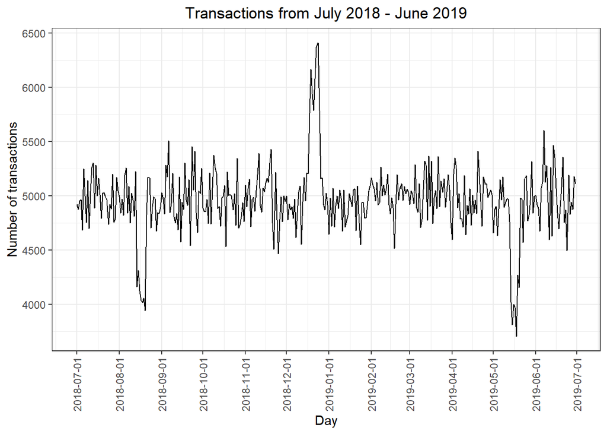

```r
ggplot(Total_Sales_D, aes(x = DATE, y = TOTAL_SALES)) +
  geom_line() +
  labs(x = "Day", y = "Number of transactions", title = "Transactions from July 2018 - June 2019") +
  scale_x_date(breaks = "1 month") +
  theme(axis.text.x = element_text(angle = 90, vjust = 0.5))
```

#Filter out the transactions that occurred in the month of December and look at individual days

```r
Total_Sales_Dec = Total_Sales_D %>% filter(DATE > "2018-11-30" & DATE < "2019-01-01")
View(Total_Sales_Dec)
```

#Plot the daily transactions in the month of December.

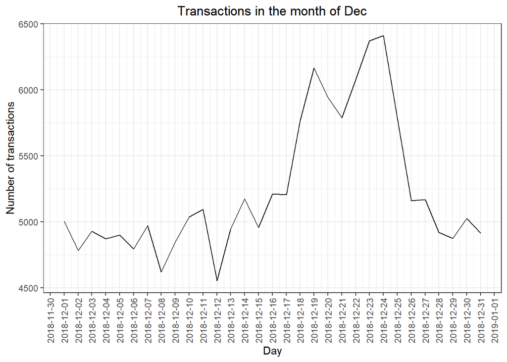

```r
ggplot(Total_Sales_Dec, aes(x = DATE, y = TOTAL_SALES)) +
  geom_line() +
  labs(x = "Day", y = "Number of transactions", title = "Transactions in the month of Dec") +
  scale_x_date(breaks = "1 day") +
  theme(axis.text.x = element_text(angle = 90, vjust = 0.5))
```

#Creating another Pack size column from the Product name column

```r
QVI_transaction_data$PACK_SIZE <- str_extract(QVI_transaction_data$PROD_NAME,  "[-+.e0-9]*\\d")
```

#Convert PACK_SIZE to numeric and sorting in ascending

```r
QVI_transaction_data$PACK_SIZE <- as.numeric(as.character(QVI_transaction_data$PACK_SIZE))
class(QVI_transaction_data$PACK_SIZE)
```

```
## [1] "numeric"
```

```r
Transaction_data = QVI_transaction_data %>% arrange(PACK_SIZE)
summary(Transaction_data$PACK_SIZE)
```

```
##    Min. 1st Qu.  Median    Mean 3rd Qu.    Max.
##    70.0   150.0   170.0   175.6   175.0   380.0
```

#Plot a histogram showing the distribution of the PACk SIZE

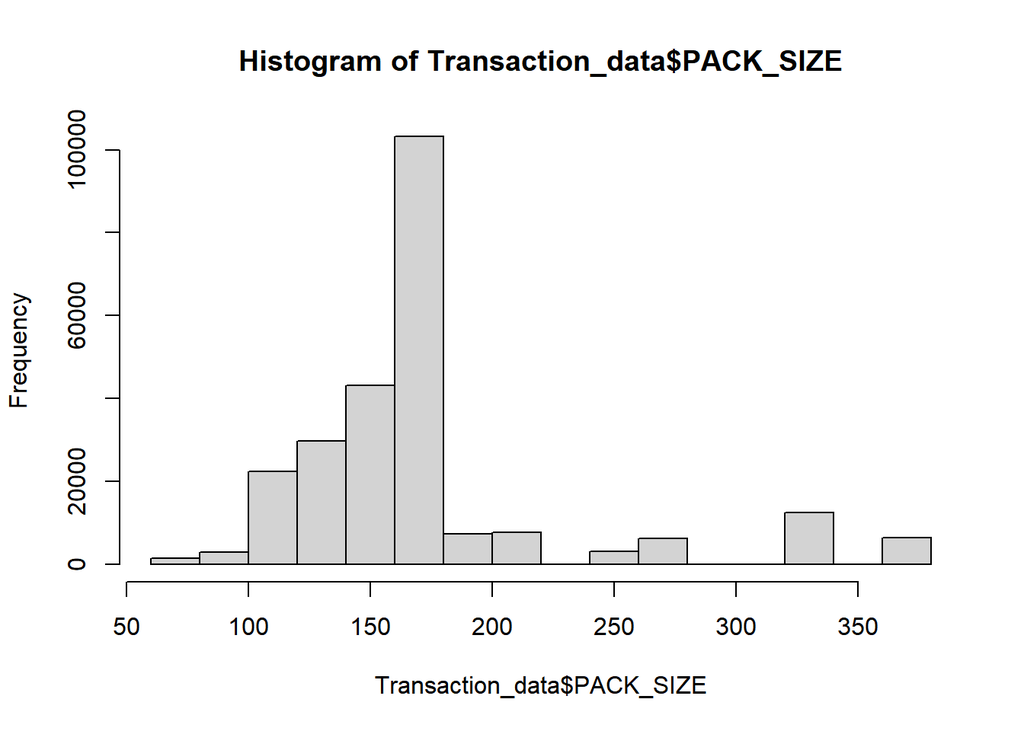

```r
hist(Transaction_data$PACK_SIZE)
```

#Creating brand using the first word from the product name column

```r
Transaction_data$BRAND <- str_extract(Transaction_data$PROD_NAME,"(\\w+)")
View(Transaction_data)
```

#Get the frequency of each brand name

```r
Brand_Name = Transaction_data %>% group_by(BRAND) %>% count(BRAND)
```

```r
Brand_Name = Brand_Name %>% arrange(n, desc(n))
View(Brand_Name)
```

#Clean Brand name to make it consistent

```r
Transaction_data$BRAND[Transaction_data$BRAND == "Red"]<-"RRD"
Transaction_data$BRAND[Transaction_data$BRAND == "Snbts"]<-"Sunbites"
Transaction_data$BRAND[Transaction_data$BRAND == "Infzns"]<-"Infuzions"
Transaction_data$BRAND[Transaction_data$BRAND == "Ww"]<-"Woolworths"
Transaction_data$BRAND[Transaction_data$BRAND == "Smith"]<-"Smiths"
Transaction_data$BRAND[Transaction_data$BRAND == "NATURAL"]<-"Natural"
Transaction_data$BRAND[Transaction_data$BRAND == "Dorito"]<-"Doritos"
Transaction_data$BRAND[Transaction_data$BRAND == "Grain"]<-"Grnwves"
```

#Get the frequency of the brand name after regularizing it.

```r
Brand_Name_C = Transaction_data %>% group_by(BRAND) %>% count(BRAND)
```

#Sorting the brand name in descending order after making regularizing it

```r
Brand_Name_C = Brand_Name_C %>% arrange(desc(n))
View(Brand_Name_C)
```

#Examine the customer dataset

```r
str(QVI_purchase_behaviour)
```

```
## spec_tbl_df [72,637 x 3] (S3: spec_tbl_df/tbl_df/tbl/data.frame)
##  $ LYLTY_CARD_NBR  : num [1:72637] 1000 1002 1003 1004 1005 ...
##  $ LIFESTAGE       : chr [1:72637] "YOUNG SINGLES/COUPLES" "YOUNG SINGLES/COUPLES" "YOUNG FAMILIES" "OLDER SINGLES/COUPLES" ...
##  $ PREMIUM_CUSTOMER: chr [1:72637] "Premium" "Mainstream" "Budget" "Mainstream" ...
##  - attr(*, "spec")=
##   .. cols(
##   ..   LYLTY_CARD_NBR = col_double(),
##   ..   LIFESTAGE = col_character(),
##   ..   PREMIUM_CUSTOMER = col_character()
##   .. )
```

```r
summary(QVI_purchase_behaviour)
```

```
##  LYLTY_CARD_NBR     LIFESTAGE         PREMIUM_CUSTOMER
##  Min.   :   1000   Length:72637       Length:72637
##  1st Qu.:  66202   Class :character   Class :character
##  Median : 134040   Mode  :character   Mode  :character
##  Mean   : 136186
##  3rd Qu.: 203375
##  Max.   :2373711
```

#Group the Lifestage column by the frequency of occurrence and plot a bar chart

```r
QVI_purchase_behaviour %>% group_by(LIFESTAGE) %>% count(LIFESTAGE) %>% arrange(desc(n))
```

| LIFESTAGE | n |
| --- | --- |
| RETIREES | 14805 |
| OLDER SINGLES/COUPLES | 14609 |
| YOUNG SINGLES/COUPLES | 14441 |
| OLDER FAMILIES | 9780 |
| YOUNG FAMILIES | 9178 |
| MIDAGE SINGLES/COUPLES | 7275 |
| NEW FAMILIES | 2549 |

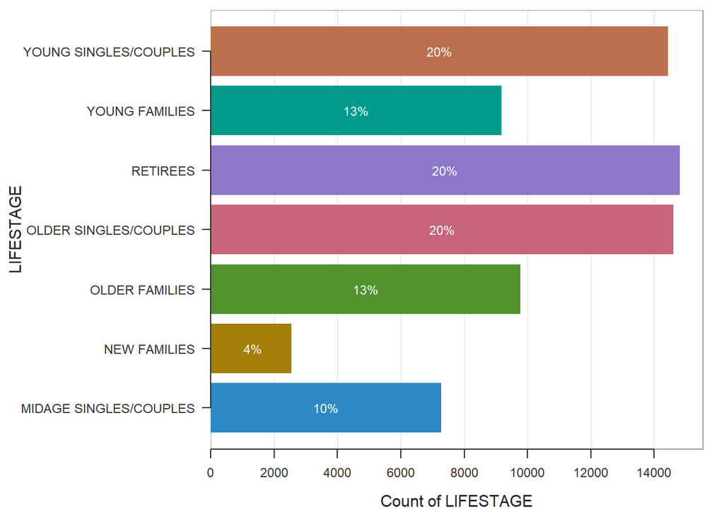

```
## >>> Suggestions
## BarChart(LIFESTAGE, horiz=TRUE)  # horizontal bar chart
## BarChart(LIFESTAGE, fill="greens")  # sequential green bars
## PieChart(LIFESTAGE)  # doughnut (ring) chart
## Plot(LIFESTAGE)  # bubble plot
## Plot(LIFESTAGE, stat="count")  # lollipop plot
##
##
## --- LIFESTAGE ---
##
##
## Missing Values of LIFESTAGE: 0
##
##
##              LIFESTAGE   Count   Prop
## --------------------------------------
## MIDAGE SINGLES/COUPLES    7275   0.100
##           NEW FAMILIES    2549   0.035
##         OLDER FAMILIES    9780   0.135
##  OLDER SINGLES/COUPLES   14609   0.201
##               RETIREES   14805   0.204
##         YOUNG FAMILIES    9178   0.126
##  YOUNG SINGLES/COUPLES   14441   0.199
## --------------------------------------
##                  Total   72637   1.000
##
##
## Chi-squared test of null hypothesis of equal probabilities
##   Chisq = 12212.642, df = 6, p-value = 0.000
```

```r
BarChart(LIFESTAGE, data=QVI_purchase_behaviour, horiz=TRUE)
```

#Group the premium customer by the frequency of occurrence and plot a bar chart

```r
QVI_purchase_behaviour %>% group_by(PREMIUM_CUSTOMER) %>% count(PREMIUM_CUSTOMER) %>% arrange(desc(n))
```

| PREMIUM_CUSTOMER | n |
| --- | --- |
| Mainstream | 29245 |
| Budget | 24470 |
| Premium | 18922 |

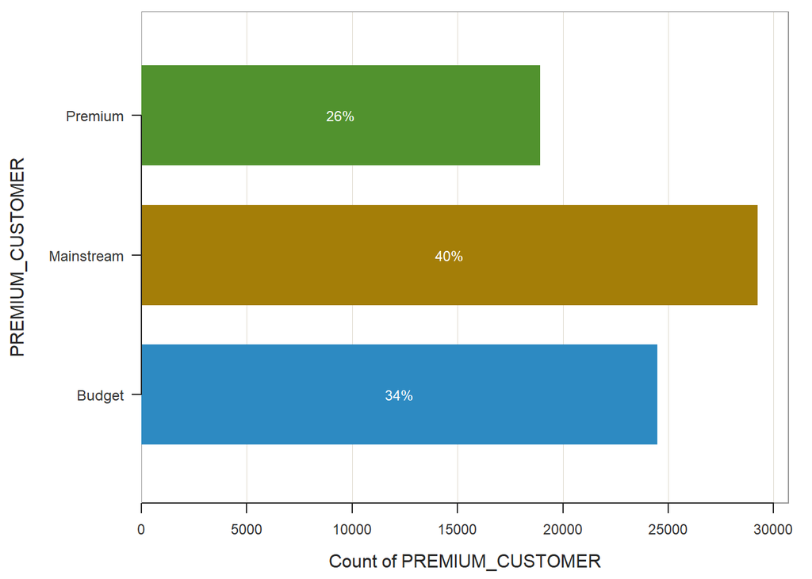

```
## >>> Suggestions
## BarChart(PREMIUM_CUSTOMER, horiz=TRUE)  # horizontal bar chart
## BarChart(PREMIUM_CUSTOMER, fill="greens")  # sequential green bars
## PieChart(PREMIUM_CUSTOMER)  # doughnut (ring) chart
## Plot(PREMIUM_CUSTOMER)  # bubble plot
## Plot(PREMIUM_CUSTOMER, stat="count")  # lollipop plot
##
##
## --- PREMIUM_CUSTOMER ---
##
##
## Missing Values of PREMIUM_CUSTOMER: 0
##
##
##                Budget  Mainstream  Premium       Total
## Frequencies:    24470       29245    18922       72637
## Proportions:    0.337       0.403    0.261       1.000
##
##
## Chi-squared test of null hypothesis of equal probabilities
##   Chisq = 2204.734, df = 2, p-value = 0.000
```

```r
BarChart(PREMIUM_CUSTOMER, data=QVI_purchase_behaviour, horiz=TRUE)
```

#Merge transaction data to purchase behavior data

```r
Data_M <- merge(Transaction_data, QVI_purchase_behaviour, by = "LYLTY_CARD_NBR")
View(Data_M)
```

#Examine the merged dataset

```r
str(Data_M)
```

```
## 'data.frame':    246740 obs. of  12 variables:
##  $ LYLTY_CARD_NBR  : num  1000 1002 1003 1003 1004 ...
##  $ DATE            : Date, format: "2018-10-17" "2018-09-16" ...
##  $ STORE_NBR       : num  1 1 1 1 1 1 1 1 1 1 ...
##  $ TXN_ID          : num  1 2 3 4 5 6 8 7 9 10 ...
##  $ PROD_NBR        : num  5 58 52 106 96 86 10 49 20 51 ...
##  $ PROD_NAME       : chr  "Natural Chip        Compny SeaSalt175g" "Red Rock Deli Chikn&Garlic Aioli 150g" "Grain Waves Sour    Cream&Chives 210G" "Natural ChipCo      Hony Soy Chckn175g" ...
##  $ PROD_QTY        : num  2 1 1 1 1 1 1 1 1 2 ...
##  $ TOT_SALES       : num  6 2.7 3.6 3 1.9 2.8 2.7 3.8 5.7 8.8 ...
##  $ PACK_SIZE       : num  175 150 210 175 160 165 150 110 330 170 ...
##  $ BRAND           : chr  "Natural" "RRD" "Grnwves" "Natural" ...
##  $ LIFESTAGE       : chr  "YOUNG SINGLES/COUPLES" "YOUNG SINGLES/COUPLES" "YOUNG FAMILIES" "YOUNG FAMILIES" ...
##  $ PREMIUM_CUSTOMER: chr  "Premium" "Mainstream" "Budget" "Budget" ...
```

```r
summary(Data_M)
```

```
##  LYLTY_CARD_NBR         DATE              STORE_NBR         TXN_ID
##  Min.   :   1000   Min.   :2018-07-01   Min.   :  1.0   Min.   :      1
##  1st Qu.:  70015   1st Qu.:2018-09-30   1st Qu.: 70.0   1st Qu.:  67569
##  Median : 130367   Median :2018-12-30   Median :130.0   Median : 135182
##  Mean   : 135530   Mean   :2018-12-30   Mean   :135.1   Mean   : 135130
##  3rd Qu.: 203083   3rd Qu.:2019-03-31   3rd Qu.:203.0   3rd Qu.: 202652
##  Max.   :2373711   Max.   :2019-06-30   Max.   :272.0   Max.   :2415841
##     PROD_NBR       PROD_NAME            PROD_QTY       TOT_SALES
##  Min.   :  1.00   Length:246740      Min.   :1.000   Min.   : 1.700
##  1st Qu.: 26.00   Class :character   1st Qu.:2.000   1st Qu.: 5.800
##  Median : 53.00   Mode  :character   Median :2.000   Median : 7.400
##  Mean   : 56.35                      Mean   :1.906   Mean   : 7.316
##  3rd Qu.: 87.00                      3rd Qu.:2.000   3rd Qu.: 8.800
##  Max.   :114.00                      Max.   :5.000   Max.   :29.500
##    PACK_SIZE        BRAND            LIFESTAGE         PREMIUM_CUSTOMER
##  Min.   : 70.0   Length:246740      Length:246740      Length:246740
##  1st Qu.:150.0   Class :character   Class :character   Class :character
##  Median :170.0   Mode  :character   Mode  :character   Mode  :character
##  Mean   :175.6
##  3rd Qu.:175.0
##  Max.   :380.0
```

#Total sales by LIFESTAGE and PREMIUM_CUSTOMER

```r
Total_Sales = Data_M %>% group_by(LIFESTAGE, PREMIUM_CUSTOMER) %>% summarise(TOTAL_SALES = sum(TOT_SALES))
View(Total_Sales)
```

#Convert the premium customer and lifestage columns from character to a factor

```r
Total_Sales$LIFESTAGE  <- as.factor(Total_Sales$LIFESTAGE)
Total_Sales$PREMIUM_CUSTOMER  <- as.factor(Total_Sales$PREMIUM_CUSTOMER)
is.factor(Total_Sales$PREMIUM_CUSTOMER)
```

```
## [1] TRUE
```

#Visualize total sale with life stages and premium customer

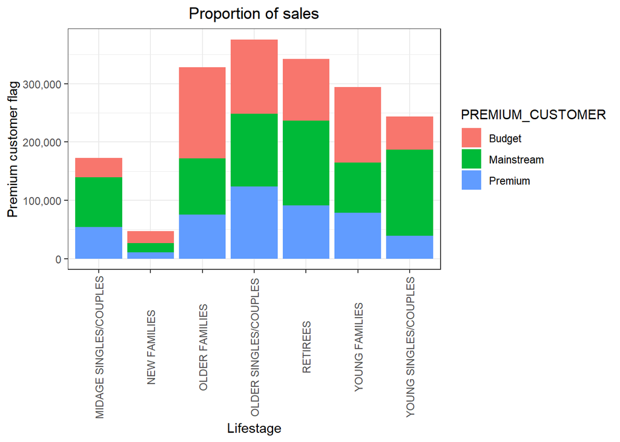

```r
Total_Sales %>% ggplot(aes(x = LIFESTAGE, y = TOTAL_SALES, fill = PREMIUM_CUSTOMER)) +
    geom_col() +
    scale_y_continuous(labels = comma) +
    labs(x = "Lifestage",
         y = "Premium customer flag",
         title = "Proportion of sales") + theme(axis.text.x = element_text(angle = 90, vjust = 0.5))
```

#Group premium customer and lifestage by the frequency of premium customer

```r
No_of_Premium_c = Data_M %>%  group_by(PREMIUM_CUSTOMER, LIFESTAGE) %>% count(PREMIUM_CUSTOMER)
View(No_of_Premium_c)
```

#Plot a bar chart showing the premium customers and the number of customers

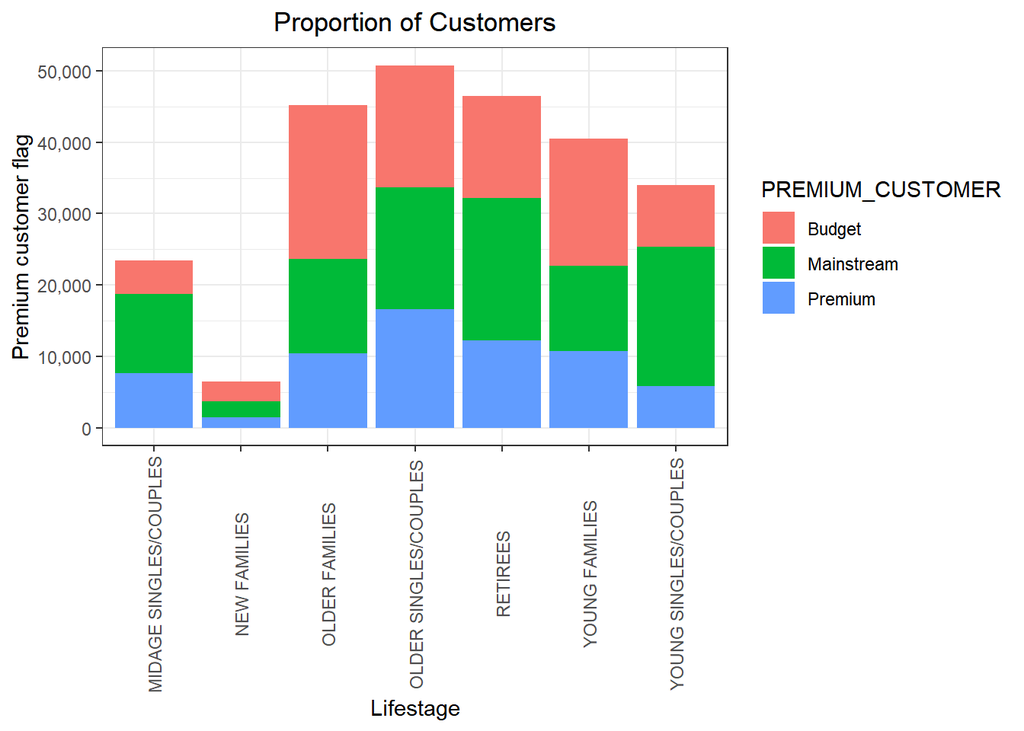

```r
No_of_Premium_c %>% ggplot(aes(x = LIFESTAGE, y = n, fill = PREMIUM_CUSTOMER)) +
  geom_col() +
  scale_y_continuous(labels = comma) +
  labs(x = "Lifestage",
       y = "Premium customer flag",
       title = "Proportion of Customers") + theme(axis.text.x = element_text(angle = 90, vjust = 0.5))
```

#Average number of units per customer by LIFESTAGE and PREMIUM_CUSTOMER

```r
Avg_Units <- Data_M %>% group_by(LIFESTAGE, PREMIUM_CUSTOMER) %>% summarise(AVG = sum(PROD_QTY)/uniqueN(LYLTY_CARD_NBR)) %>% arrange(desc(AVG))
View(Avg_Units)
```

#Plot a bar chart for Avg units per customer by lifestage and premium customer

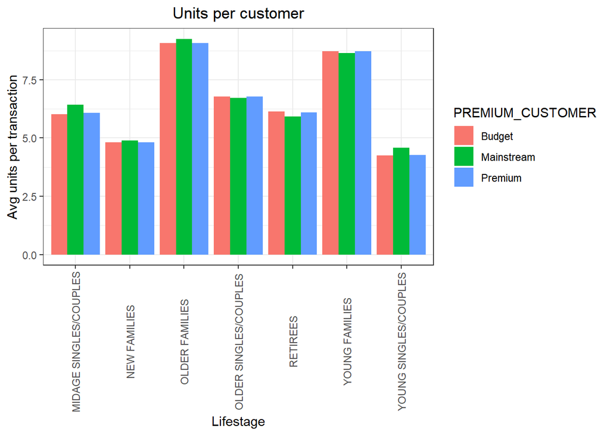

```r
  ggplot(data = Avg_Units, aes(weight = AVG, x = LIFESTAGE, fill = PREMIUM_CUSTOMER)) +
  geom_bar(position = position_dodge()) +
  labs(x = "Lifestage", y = "Avg units per transaction", title = "Units per customer") +
  theme(axis.text.x = element_text(angle = 90, vjust = 0.5))
```

#Exame average price by per unit by LIFESTAGE and PREMIUM_CUSTOMER

```r
AVG_PRICE <- Data_M %>% group_by(LIFESTAGE, PREMIUM_CUSTOMER) %>% summarise(Avg = sum(TOT_SALES)/sum(PROD_QTY)) %>% arrange(desc(Avg))
View(AVG_PRICE)
```

#Plot a chart showing the average price by Lifestage and premium customer

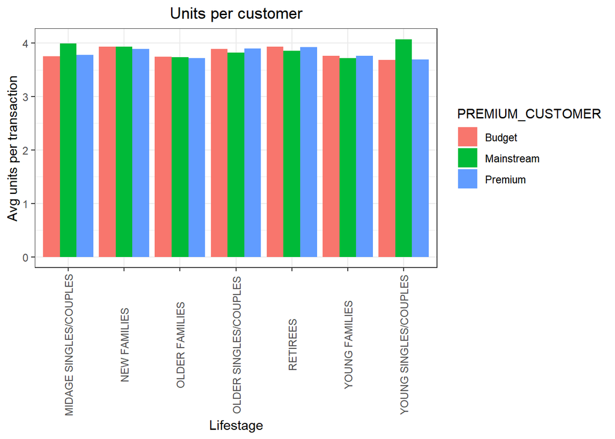

```r
ggplot(data = AVG_PRICE, aes(weight = Avg, x = LIFESTAGE, fill = PREMIUM_CUSTOMER)) +
  geom_bar(position = position_dodge()) +
  labs(x = "Lifestage", y = "Avg units per transaction", title = "Units per customer") +
  theme(axis.text.x = element_text(angle = 90, vjust = 0.5))
```

## Findings

- 2018-12-25 is missing in the DATE column and it’s assumed that the store was closed on Christmas day.
- Sales increased in the days before Christmas day.
- Sales are mainly coming from older families (budget), retirees (mainstream) and young singles/couples (mainstream).
- Mainstream retirees and mainstream young singles/couples contribute more to the sales and it isn’t the case with older families budget.
- Each of the premium segment in older families and young families buy more chips.
- Mainstream mid-age single/couples and mainstream young singles/couples spend more per chips compared to other premium customers in their category.